# Homework 3

# Fixed Plot of LifeExp vs GdpPerCap Graph

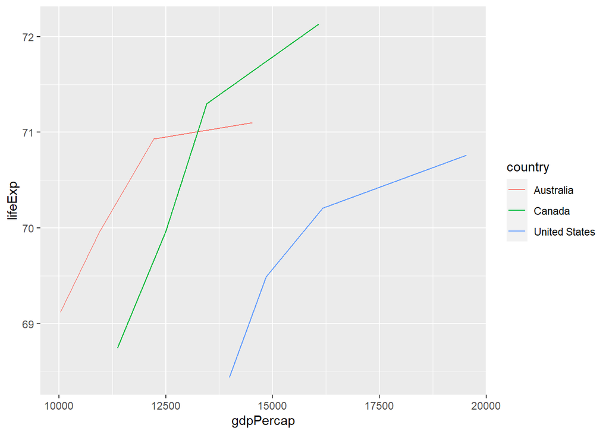

```r
us_data %>% ggplot(aes(x = gdpPercap, y = lifeExp, colour = country)) + geom_line() +
  geom_line(data = data_fixed %>% filter(country %in% c("Canada", "Australia")))
```

# Q.3 - Paragraph

Data science is the work of manipulating, analyzing, and extracting relevant data available from any unstructured format in a way that would be beneficial/insightful to the person of interest. This could range anywhere from basic spreadsheet chart plots to statistic-driven programs like machine learning and so forth. In essence, any data science work would encompass a few criteria as listed.

1. Gathering relevant data for selected problem
2. Cleaning and processing of data
3. Explore and analyze the data
4. Building a model for prediction/forecasting
5. Utilize the results in a meaningful manner

For instance, the recently publicly released OpenAI chatbot, ChatGPT, is an actualization of data science that utilizes countless datasets on online speech patterns to train and replicate that on a machine. ChatGPT is trained through a process of human feedback (RLHF) in order to predict and also provide answers/conversation in a humanlike nature.

[figure not shown]